# Awr1642-oob-non-os Users Guide

## Table of Contents

**NOTE: ES2.0 devices only**  
This version of the mmWave Demo lab will work only with xWR1642BOOST ES2.0 EVMs, which require **mmWave SDK version 2.0 or above.**

# Overview

- This lab exercise demonstrates the non-OS version of mmw demo running on AWR1642 mmWave Sensor.
- In this application TI-RTOS is removed from MSS & DSS driver and application code.
- The application showcase SDK driver OSAL implementation with Non OS routines and how mmw application can run in single threaded environment.

Application’s features:

- mmWave Layer is removed from MSS and DSS application. It directly uses mmWaveLink to Program Radar Front end.
- DSS runs mmWaveLink instance on it, which does RadarSS configuration. It receives all the CLI commands from MSS over mailbox.
- No changes are required in drivers and libraries of mmWave SDK to work in non-OS environment. OSAL source & library for Non-OS are provided in the same package.
- Interrupt(VIM) and Timer(RTI) driver were part of TI RTOS and hence to remove TI RTOS, implementation of these drivers are included in the application code.

Application’s limitation compared to mmw demo of mmWave SDK v2.0:

- Dynamic sensor-stop over CLI is not possible as there is no multi-thread in this application to listen any further CLI command while MSS is busy pumping object data over UART. So to stop the frame or to change the configuration, user needs to restart the device and send updated CLI commands.
- This demo provides a reference to implement datapath configuration and processing chain without any OS. It doesn’t include LVDS streaming, CQ & Analog monitoring features.

## Startup & OSAL

### Startup Sequence

In case of default mmw demo, OS takes care of startup sequence but in Non-OS demo it needs to implement its own startup sequence.

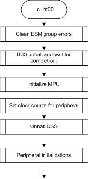

### OSAL

To avoid modification of drivers, this package provides OSAL implementation for Non-OS environment which has equivalent OS calls like Semaphore, Event, Memory etc.

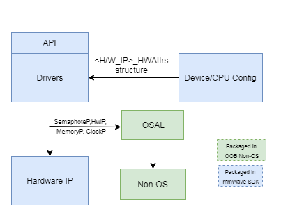

## Application Control Flow

- Control flow of OOB Non-OS at MSS and DSS cores are shown here:

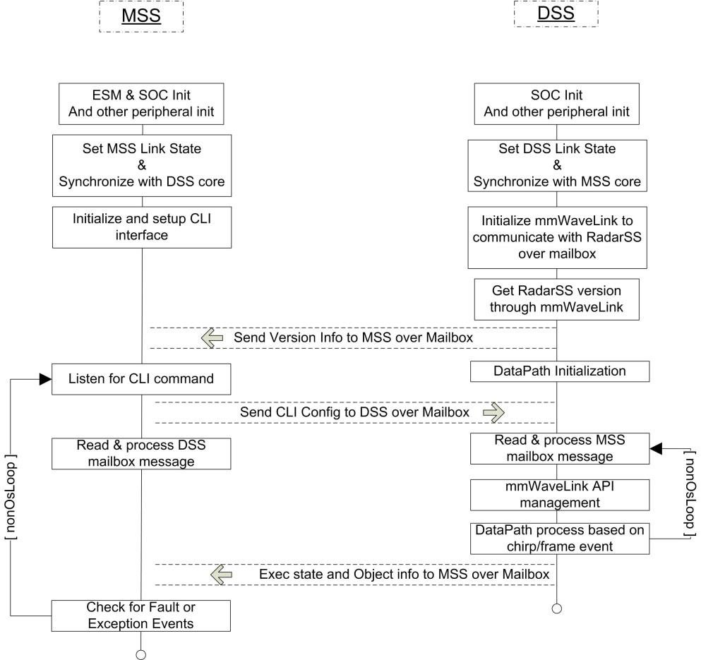

- DataPath processing chain is same as default mmw demo, please refer doxygen document available in mmWave-SDK.
- The following plots are available:
  - Scatter Plot
  - Range Profile
  - Noise Profile
  - Range Azimuth Heat Map
  - Range Doppler Heat Map
  - Statistics

## OSAL Implementation with Non-OS Environment

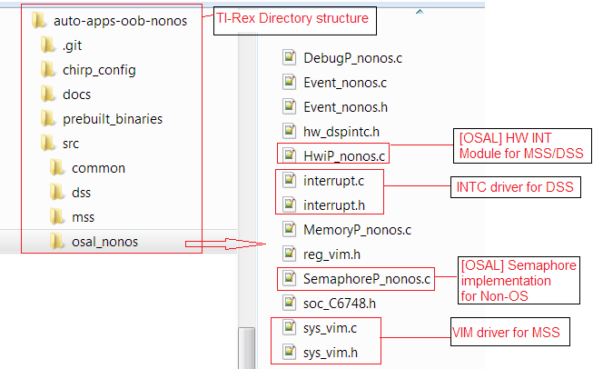

## Memory Comparison with OS Application

| Free Memory | Non-OS | OS |
| --- | --- | --- |
| **DSS** |  |  |
| L2-UMAP1 [128KB] | 14.8 KB | 1.28 KB |
| L2-UMAP0 [128KB] | 60 KB | 35.5 KB |
| L1P-SRAM | 7.7 KB | 1.1 KB |
| L3-SRAM | 389.6 KB | 381.8 KB |
| **MSS** |  |  |
| PROG_RAM | 209 KB | 172 KB |
| DATA_RAM | 178 KB | 133 KB |
| MetaImage Size | 196 KB | 264 KB |

Note: In this comparison LVDS and Monitoring features are removed at DSS app.

# Software

- **Pre-requisites**
  - [TI mmWave SDK](https://www.ti.com/tool/MMWAVE-SDK) specified in Lab release notes, and all related dependencies installed as mentioned in the mmWave SDK release notes.
- [Google Chrome](https://www.google.com/chrome/) with TI Cloud Agent Extension
  - For running the mmWave Demo Visualizer
  - Download from [TI Cloud Agent](https://software-dl.ti.com/ccs/esd/documents/ti_cloud_agent.html) or install when accessing the [demo](https://dev.ti.com/gallery/view/mmwave/mmWave_Demo_Visualizer)
- mmWave SDK Demo
  - Download from [TI Resource Explorer](https://dev.ti.com/tirex)
- UniFlash
  - For flashing firmware images onto
  - Download from [TI.com/tool/uniflash](https://www.ti.com/tool/UNIFLASH)
- XDS110 Drivers
  - For EVM XDS device support
  - Included with CCS Installation, or standalone through [TI XDS Emulation Software](https://software-dl.ti.com/ccs/esd/documents/xdsdebugprobes/emu_xds_software_package_download.html)

# Hardware

- xWR16xx ES2.0 EVM
- Micro USB cable (included in the EVM package)
- 5V/2.5A Power Supply
  - Purchase from [Digikey](https://www.digikey.com/en/products/detail/cuiinc/SMI36-5-V-P5/5415060)

# Software Setup

## 1. Pre-requisites

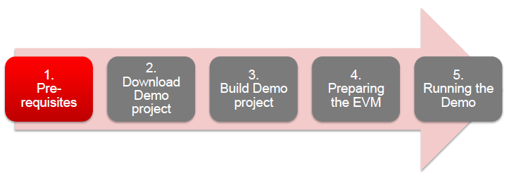

It is assumed that you have the mmWave SDK specified in Lab release notes and all related dependencies installed as mentioned in the mmWave SDK release notes.

- The mmWave SDK release notes include the links for downloading the required tools.

Helpful Tips

- Beginning with SDK 1.1.0.2, the mmwave SDK installer automatically installs the correct versions of the required tools (except CCS).
- Beginning with SDK 1.1.0.2, PERL and crc.pm are no longer required.

| Tool | Version | Download Link |
| --- | --- | --- |
| mmWave SDK | 2.0.0.4 | [download link](https://www.ti.com/tool/MMWAVE-SDK) |
| CCS | 7.4 or later | [download link](https://www.ti.com/tool/download/CCSTUDIO) |
| TI ARM Compiler | 16.9.6.LTS | Included in mmwave sdk installer |
| TI CGT Compiler | 8.1.3 | Included in mmwave sdk installer |
| XDC | 3.50.04.43 | Included in mmwave sdk installer |
| C64x+ DSPLIB | 3.4.0.0 | Included in mmwave sdk installer |
| C674x DSPLIB | 3.4.0.0 | Included in mmwave sdk installer |
| C674x MATHLIB (little-endian, elf/coff format) | 3.1.2.1 | Included in mmwave sdk installer |
| mmwave Radar device support packages | 1.5.9 or later | Upgrade to the latest using CCS update process (see SDK user guide for more details) |
| TI Emulators package | 7.0.188.0 or later | Upgrade to the latest using CCS update process (see SDK user guide for more details) |
| Uniflash | latest | Uniflash tool is used for flashing xWR1xxx devices Cloud version (Recommended): https://dev.ti.com/uniflash Offline version: http://www.ti.com/tool/uniflash |
| mmWave Demo Visualizer | latest | TI Gallery APP for configuring mmWave sensors and visualizing the point cloud objects generated by the mmWave SDK demo https://dev.ti.com/mmWaveDemoVisualizer |

```
If you have already installed the mmWave SDK and all the required tools, you can move on to the next step i.e. downloading the lab on to your machine.
```

## 2. Downloading the Lab Project

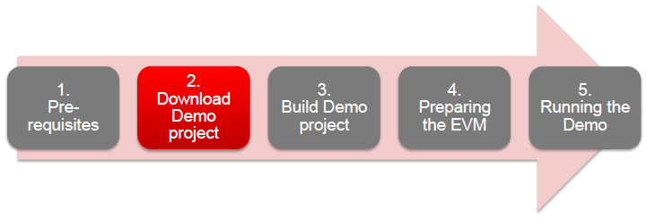

The nonOS-oob projects are available in the Radar Toolbox.

[figure not shown]

[figure not shown]

- Select the **16xx nonOS OOB** demo in the left view.
- The right view shows the contents of the Lab which contains the CCS Project and the PC GUI.
- Click on the **Download and Install** button in the top right corner as shown.
- Select the **Make Available Offline** option from the drop down to start downloading the Lab.

[figure not shown]

The AWR16xx nonOS OOB Demo consists of two CCS projects, one for the R4F core and one for the C674x DSP core.

- The project will be downloaded in `C:\ti\radar_toolbox`
- Select the CCS Project MSS file in the left view
- Click on the **Import to IDE** button which should be visible in the right side view after a successful download.
  - This copies the project in the user’s workspace and imports it into the CCS project explorer.
  - It is important to note that the copy created in the workspace is the one that gets imported in CCS. The original project downloaded from the toolbox is not modified.
- Repeat with the CCS Project DSS file
- After successfully completing the **Import to IDE** operation, the both projects should be visible in CCS Project Explorer as shown here.

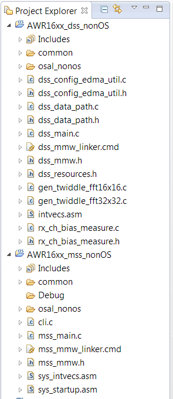

- At this point, we have successfully downloaded the nonOS OOB demo and imported it in CCS.
- We are ready to move on to the next step i.e. Building the projects.

## 3. Building the Project

[figure not shown]

With the AWR16xx_dss_nonOS project selected in Project Explorer, right click on the project and select **Rebuild Project.**

- Selecting Rebuild instead of Build ensures that the project is always re-compiled. This is especially important in case the previous build failed with errors.

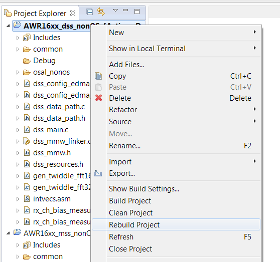

- `xwr16xx_mmw_dss_nonOS.xe674`
- `xwr16xx_mmw_dss_nonOS.bin`
  - (note, this image is not flashed directly. It is merged into a combined meta image when building the MSS; shown on the next page).

If the build fails with errors, please ensure that all the pre-requisites are installed as mentioned in the mmWave SDK release notes.

- Please note that pre-built binary files are provided with the demo under mmwave SDK.
- Look under `<MMWAVE_SDK3_INSTALL_DIR>\packages\ti\demo\xwr16xx\mmw`

The AWR16xx_dss_nonOS project must be built BEFORE the AWR16xx_mmw_nonOS project is built.

- With the AWR16xx_mmw_nonOS project selected in Project Explorer, right click on the project and select **Rebuild Project.**

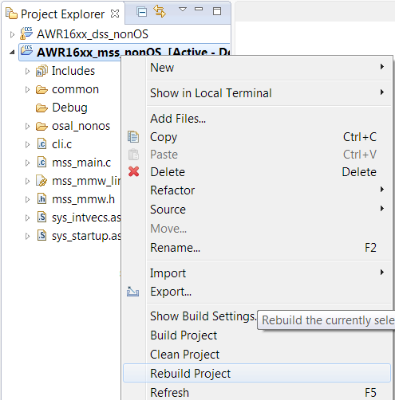

On successful completion of the MSS build, you should see the output in CCS console as shown here and the following three files should be produced in the project debug directory:

- `xwr16xx_mmw_mss_nonOS.xer4f`
- `xwr16xx_mmw_nonOS.bin`
- `xwr16xx_mmw_nonOS.bin` (this is the meta image to be flashed)

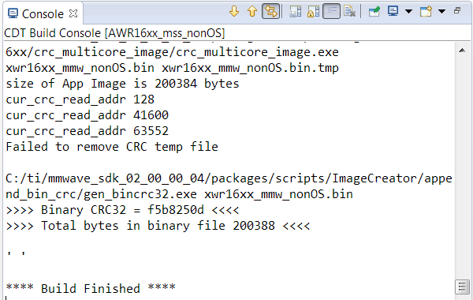

If the build fails with errors, please ensure that all the pre-requisites are installed as mentioned in the mmWave SDK release notes.

- Please note that pre-built binary files are provided with the demo under mmwave SDK.
- Look under `<MMWAVE_SDK3_INSTALL_DIR>\packages\ti\demo\xwr16xx\mmw`

# Hardware Setup

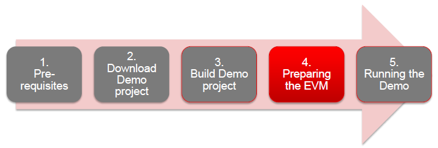

## 4.1 Preparing the EVM

There are two ways to execute the compiled code on the EVM:

- **Deployment mode:** Flashing the binary (.bin image) on to the EVM serial flash
  - In this mode, the EVM boots autonomously from flash and starts running the bin image.
- **Debug mode:** Downloading and running the executable (.xer4f image and .xe674) from CCS.
  - You will need to flash a small CCS debug firmware on the EVM (one time) to allow connecting with CCS. This debug firmware image is provided with the mmWave SDK.

As a recap, the build process in Step 3 produces the .bin .xer4f and .xe674 images.

This section explains the second method i.e. Debug mode (CCS).

- To prepare the EVM for debug mode, we start with flashing the CCS debug firmware image.
- Please note that the same flashing process can be used to flash the Lab binary to run it in deployment mode.

## 4.2 Connecting the EVM

- Power on the EVM using a 5V/2.5A power supply.
- Connect the EVM to your PC and check the COM ports in Windows Device Manager.

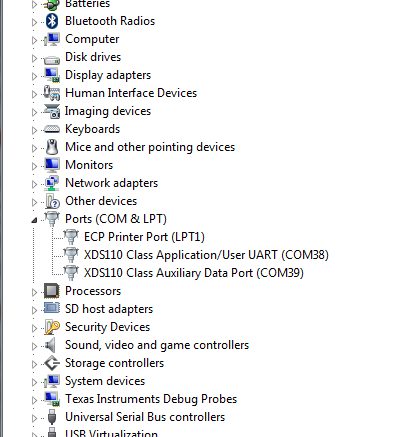

- The EVM exports two virtual COM ports as shown below:
  - XDS110 Class Application/User UART (COM<sub>UART</sub>): Used for passing configuration data and firmware to the EVM
  - XDS110 Class Auxiliary Data Port (COM<sub>AUX</sub>): Used to send processed radar data output
- Note the COM<sub>UART</sub> and COM<sub>AUX</sub> port numbers, as they will be used later for flashing and running the Lab.
  - **COM<sub>UART</sub>**: COM38
  - **COM<sub>AUX</sub>**: COM39
- The actual port numbers on your machine may be different.

## 4.3 Flashing CCS Debug Firmware

- Put the EVM in flashing mode by connecting jumpers on SOP0 and SOP2 as shown in the image.

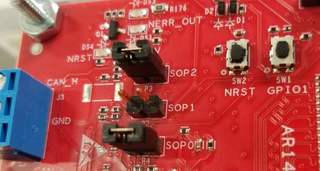

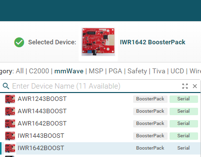

- Click **Start** to proceed
- In the **Program** tab, browse and locate the Radar SS and MSS images shown below:

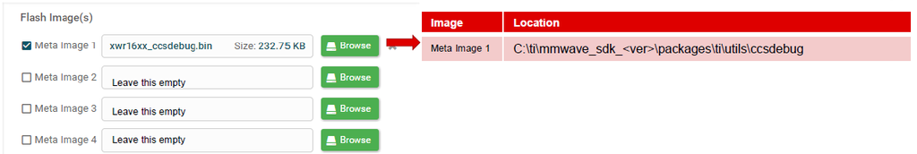

- In the **Settings & Utilities** tab, fill the **COM Port** text box with the Application/User UART COM port number **(COM<sub>UART</sub>)** noted earlier

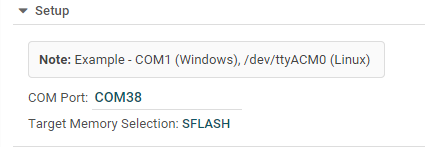

- Return to the **Program** tab, power cycle the device and click on **Load Images**
- When the flash procedure completes, UniFlash’s console should indicate: *[SUCCESS] Program Load completed successfully*
- Power off the board and remove the jumper from only header **SOP2.** Power the board back on (this puts the board back in functional mode)

# Running the Demo

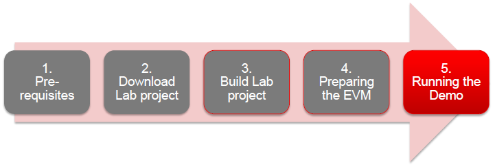

## 5.1 Connecting EVM to CCS

It is assumed that you were able to download and build the Lab in CCS (completed steps 1, 2 and 3).

To connect the Radar EVM to CCS, we need to create a target configuration.

[figure not shown]

- Go to **File ► New ► New Target Configuration File**
- Name the target configuration accordingly and check the “Use shared location” checkbox. Press Finish.

In the configuration editor window:

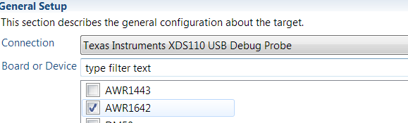

- Select “Texas Instruments XDS110 USB Debug Probe” for **Connection**
- Select **IWR1642** or **AWR1642** in the **Board or Device** list
- Press the **Save** button to save the target configuration.
- You can press the **Test Connection** button to check the connection with the board.
- Go to **View ► Target Configurations** to open the target configuration window.
- You should see your target configuration under **User Defined** configurations.

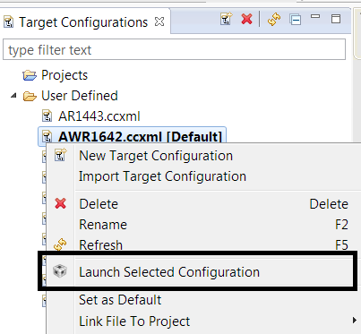

- With the board powered on, right click on the target configuration and select **Launch Select Configuration.**
- This will launch the target configuration in the debug window.

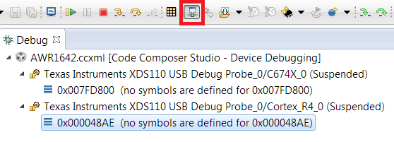

- Select the Texas Instruments XDS110 USB Debug probe/C674X_0 and press the **Connect Target** button.
- Select the Texas Instruments XDS110 USB Debug probe/Cortex_R4_0and press the **Connect Target** button.

## 5.2 Loading the Binary

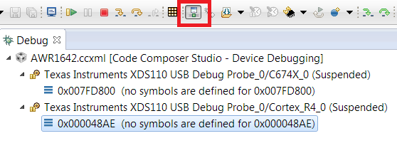

- Once both targets are connected, select the C674X_0 target, and click on the **Load** button in the toolbar.

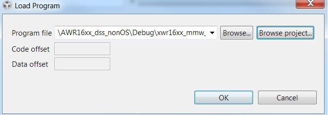

- In the **Load Program** dialog, press the **Browse Project** button.

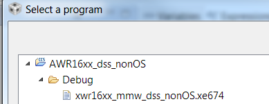

- Select the lab executable (.xe674) found in the AWR16xx_dss_nonOS project as shown, and press OK.
- Press OK again in the **Load Program** dialog.

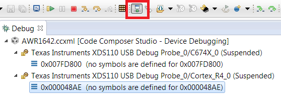

- Now select the Cortex_R4_0 target, and click on the **Load** button in the toolbar.

[figure not shown]

- In the **Load Program** dialog, press the **Browse Project** button.

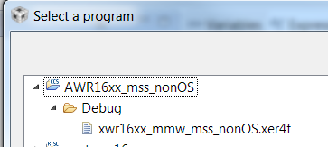

- Select the lab executable (.xer4f) found in the AWR16xx_mss_nonOS project as shown, and press OK.
- Press OK again in the **Load Program** dialog.